# Coast Buffer

```r
pacman::p_load("tigris")
pacman::p_load("sf")
pacman::p_load("tidyverse")
```

Download the coastline data using the `tigris` package. This grabs data from the US Census. Here I transform to the [US National Atlas coordinate system](https://epsg.io/2163) and then extract only the Atlantic coast.

```r
coastline.sf <- coastline() %>%
  st_as_sf() %>%
  st_transform(crs = 2163)
coastline.atlantic <- coastline.sf %>%
  filter(NAME == "Atlantic")
```

Plot the coast. I use `st_simplify` to reduce the complexity of the polygons. This greatly speeds up plotting.

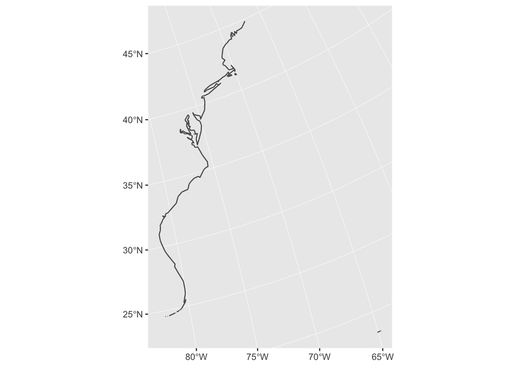

```r
ggplot() +
  geom_sf(data = coastline.atlantic %>% st_simplify(dTolerance = 1e4))
```

Now we create a set of polygons that buffer each of the coastline line segments. We have to make the spatial set union of those polygons to make a single buffer (plus an extra for Puerto Rico).

```r
atlantic.buffer <- coastline.atlantic %>%
  st_buffer(1e5) %>%
  st_union() %>%
  st_sf()  # units are meters
```

Plot them together.

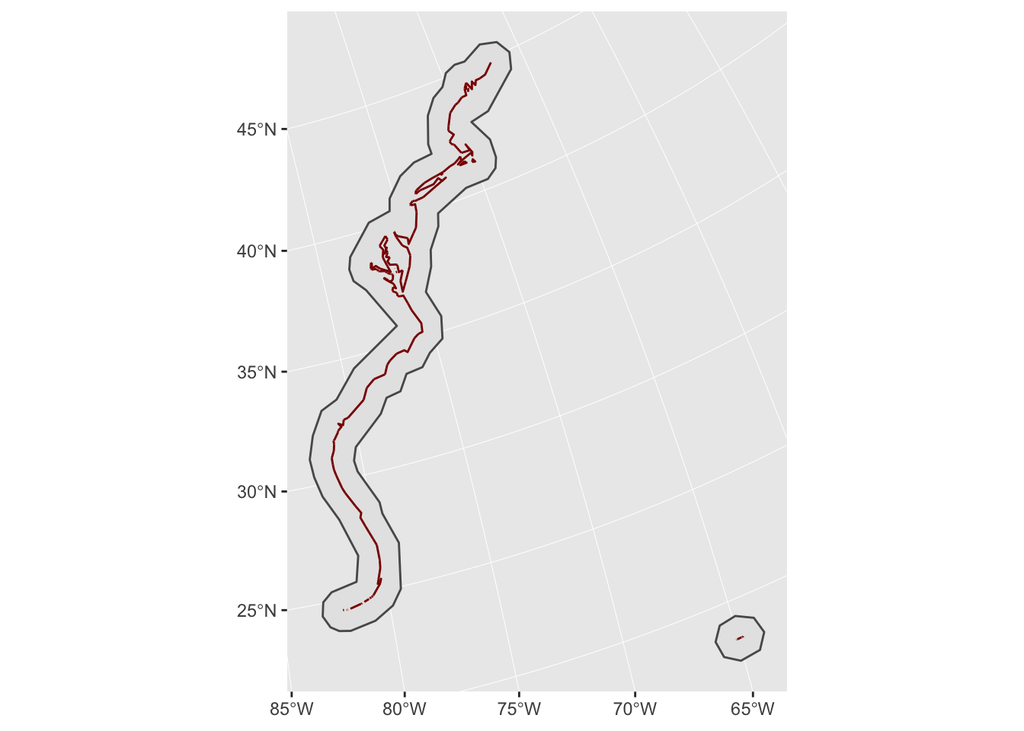

```r
ggplot() +
  geom_sf(data = atlantic.buffer %>% st_simplify(dTolerance = 1e4)) +
  geom_sf(data = coastline.atlantic %>% st_simplify(dTolerance = 1e4), color = "darkred")
```

Now we grab the national borders and internal divisions. It is key to transform into the same CRS.

```r
nat <- nation() %>%
  st_as_sf() %>%
  st_transform(crs = 2163)
divs <- divisions() %>%
  st_as_sf() %>%
  st_transform(crs = 2163)
```

By interesecting the buffer with the boundaries, we clip off the part of the buffer that is over the ocean.

```r
buf_int <- st_intersection(atlantic.buffer, divs)
```

Again plot it, this time limiting the plot area to the buffer region.

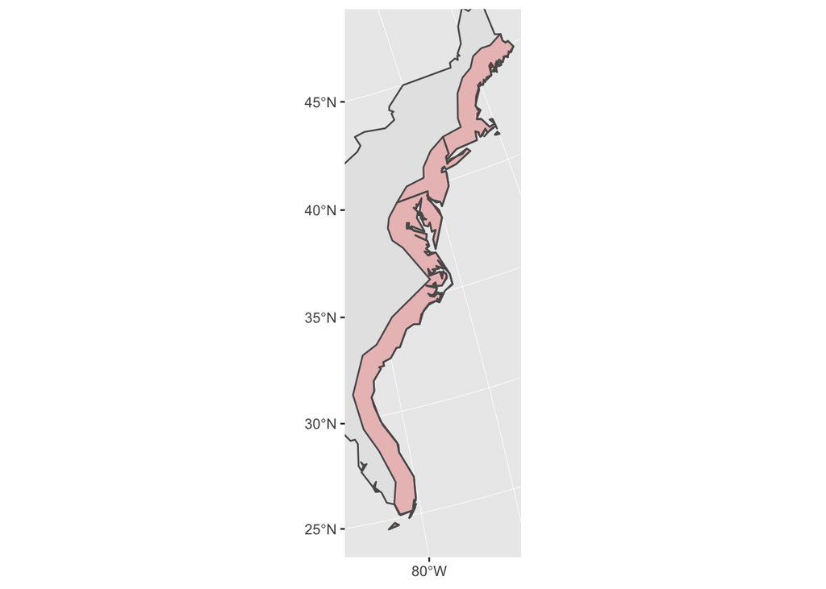

```r
ggplot() +
  geom_sf(data = nat %>% st_simplify(dTolerance = 1e4)) +
  geom_sf(data = buf_int %>% st_simplify(dTolerance = 1e4), fill = "red", alpha = 0.2) +
  lims(x = st_bbox(buf_int)[c(1, 3)], y = st_bbox(buf_int)[c(2, 4)])
```

Now for all coastlines.

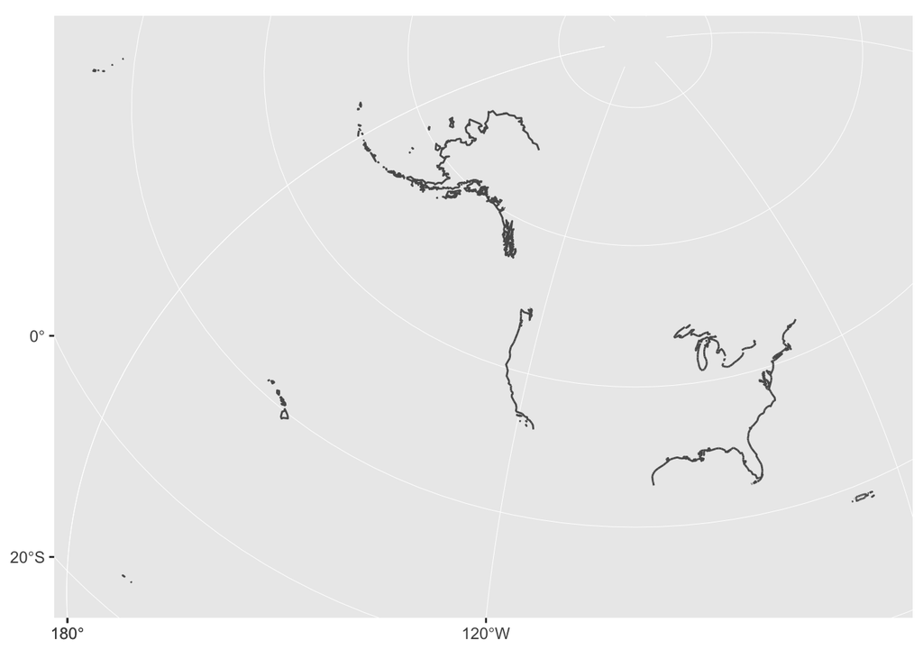

```r
ggplot() +
  geom_sf(data = coastline.sf %>% st_simplify(dTolerance = 1e4))
```

As before, except with all coastlines.

```r
all.buffer <- coastline.sf %>% st_buffer(1e5) %>% st_union() %>% st_sf()
```

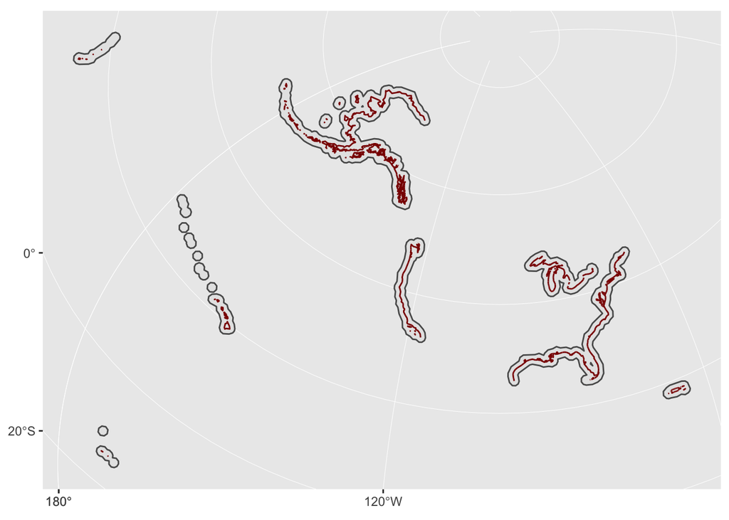

```r
ggplot() +
  geom_sf(data = all.buffer %>% st_simplify(dTolerance = 1e4)) +
  geom_sf(data = coastline.sf %>% st_simplify(dTolerance = 1e4), color = "darkred")
```

```r
all_buf_int <- st_intersection(all.buffer, divs)
```

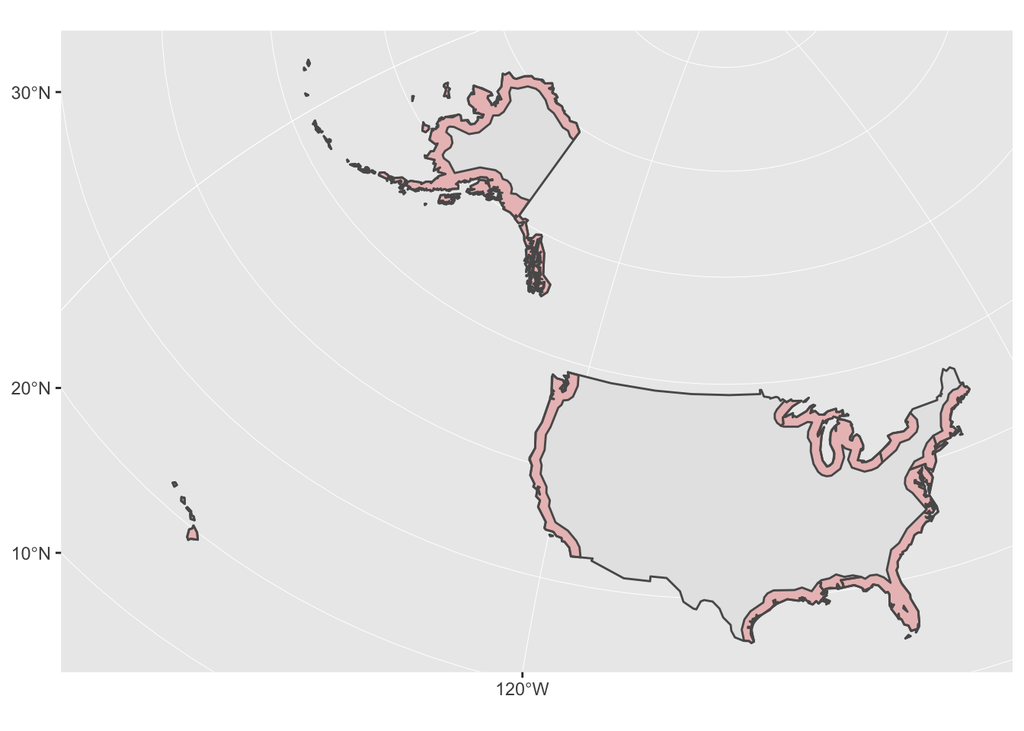

```r
ggplot() +
  geom_sf(data = nat %>% st_simplify(dTolerance = 1e4)) +
  geom_sf(data = all_buf_int %>% st_simplify(dTolerance = 1e4), fill = "red", alpha = 0.2) +
  lims(x = st_bbox(all_buf_int)[c(1, 3)], y = st_bbox(all_buf_int)[c(2, 4)])
```

We could try to filter out all of the parts of the US not of interest using `dplyr::filter`.

```r
states.sf <- states() %>% st_as_sf() %>% st_transform(crs = 2163)
# states.sf %>% filter(!NAME %in% c("Hawaii", "Puerto Rico"))
```

Plot the final output.

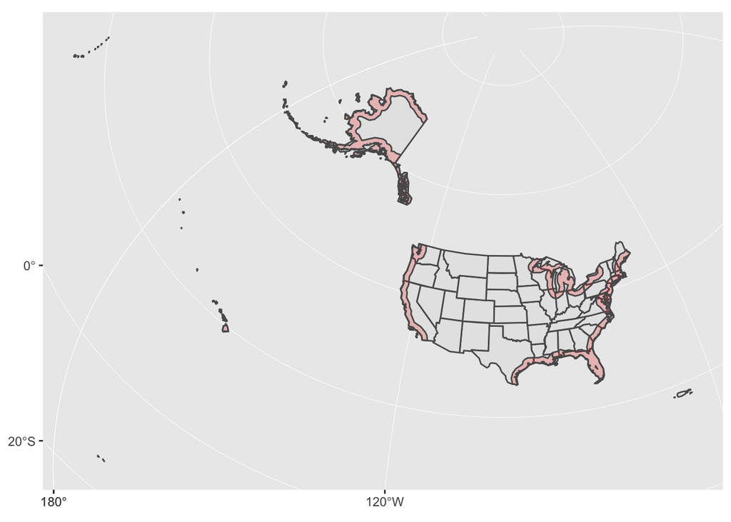

```r
ggplot() +
  geom_sf(data = states.sf %>% st_simplify(dTolerance = 1e4)) +
  geom_sf(data = all_buf_int %>% st_simplify(dTolerance = 1e4), fill = "red", alpha = 0.2) +
  lims(x = st_bbox(states.sf)[c(1, 3)], y = st_bbox(states.sf)[c(2, 4)])
```